# Statistical Methods and Data Analysis in Developmental Psychology

Lab 9

Filippo Gambarota

Updated on 2023-05-16

```r
devtools::load_all() # if using the rproject dowloaded from the slides
# source("utils-glm.R") # if using a standard setup
library(here)
library(tidyr) # for data manipulation
library(dplyr) # for data manipulation
library(ggplot2) # plotting
library(car) # general utilities
library(effects) # for extracting and plotting effects
library(emmeans) # for marginal means
```

# Overview

We are gonna work with the `admission.csv` dataset containing $n = 400$ students for the admission to the UCLA University. A researcher is interested in how variables, such as `gre` (Graduate Record Exam scores), `gpa` (GPA), `rank` (prestige of the undergraduate institution) have an influence for the admission into graduate school. The response variable, admit/don’t admit, is a binary variable.

…(continue from lab 8)

1. Fitting the model with interactions
2. Plotting results
3. Interpreting the parameters
4. Model comparison for the interactions effect

# 0. Importing data

We need to set the **working directory** on the root of the course folder using `set.wd()`. Using R Projects is just necessary to open the `.RProj` file and the working directory will be automatically correctly selected.

```r
# relevant steps of the previous lab
admission <- read.csv(here("data", "admission.csv"), header=TRUE)
admission$rankc <- factor(admission$rank, levels = 1:4, labels = 1:4)
```

# 1. Fitting model with interactions

Here we fit the two 2-way interactions between `gpa`, `gre` and `rankc`. Let’s start from only one interaction:

```r
# gpa * rankc + gre

fit1 <- glm(admit ~ gre + gpa + rankc + gpa:rankc, family = binomial(link = "logit"), data = admission)
# this is equivalent to
# fit1 <- glm(admit ~ gpa * rankc + gre, family = binomial(link = "logit"), data = admission)
summary(fit1)
```

```
##
## Call:
## glm(formula = admit ~ gre + gpa + rankc + gpa:rankc, family = binomial(link = "logit"),
##     data = admission)
##
## Deviance Residuals:
##     Min       1Q   Median       3Q      Max
## -1.6997  -0.8669  -0.6426   1.1582   2.1061
##
## Coefficients:
##               Estimate Std. Error z value Pr(>|z|)
## (Intercept) -6.5706011  3.5059016  -1.874   0.0609 .
## gre          0.0019573  0.0009179   2.132   0.0330 *
## gpa          0.9832606  0.6600694   1.490   0.1363
## rankc2       0.9869986  4.2059206   0.235   0.8145
## rankc3       1.2269661  4.5908870   0.267   0.7893
## rankc4      -1.5086918  5.9313652  -0.254   0.7992
## gpa:rankc2  -0.3089665  0.7805070  -0.396   0.6922
## gpa:rankc3  -0.4734705  0.8450248  -0.560   0.5753
## gpa:rankc4  -0.0057418  1.1023671  -0.005   0.9958
## ---
## Signif. codes:  0 '***' 0.001 '**' 0.01 '*' 0.05 '.' 0.1 ' ' 1
##
## (Dispersion parameter for binomial family taken to be 1)
##
##     Null deviance: 499.98  on 399  degrees of freedom
## Residual deviance: 457.86  on 391  degrees of freedom
## AIC: 475.86
##
## Number of Fisher Scoring iterations: 4
```

# 2. Plotting results

With interactions it is even more important and useful to plot the effects before anything else:

```r
plot(effects::allEffects(fit1))
```

[figure not shown]

The plot on the left represent the main effect of `gre` and the plot on the right is the interaction between `gpa` and `rankc`. In this case we have an interaction between a numerical and a categorical variable. The model is essentially estimating the relationship between `gpa` and `admit` splitting by the level of `rankc`.

# 3. Interpreting the parameters

The interpretation of interactions (especially with categorical variables) from model parameters is not always easy because it depends on which **contrasts** are used. By default, R uses **dummy coding** where the reference level of the factor (`rankc`) is the first category and all the other categories are compared to the reference. This influence also other parameters:

- `(Intercept)`: log odds of being admitted for `gpa = 0`, `gre = 0` and `rankc` at the reference (i.e., 1)
- `gpa`: the increase in log odds of being admitted for a unit increase in the `gpa` for people in the reference level of `rankc` (i.e., 1)
- `gre`: the increase in log odds of being admitted for a unit increase in the `gre` for people in the reference level of `rankc` (i.e., 1)
- `rankc2`: is the difference in the log odds of being admitted between `rankc2` and `rankc1` (i.e. is the log odds ratio) when `gpa` and `gre` are 0
- `rankc3`: is the difference in the log odds of being admitted between `rankc3` and `rankc1` (i.e. is the log odds ratio) when `gpa` and `gre` are 0
- `rankc4`: is the difference in the log odds of being admitted between `rankc4` and `rankc1` (i.e. is the log odds ratio) when `gpa` and `gre` are 0
- `gpa:rankc2`: the difference between `rankc` 2 and 1 in the rate of increase of the log odds of being admitted for a unit increase in the `gpa`
- `gpa:rankc3`: the difference between `rankc` 3 and 1 in the rate of increase of the log odds of being admitted for a unit increase in the `gpa`
- `gpa:rankc4`: the difference between `rankc` 4 and 1 in the rate of increase of the log odds of being admitted for a unit increase in the `gpa`

For complex interactions like this, a suggestion is to plot the effects (as we did before) and to estimate the individual slopes checking if the interpretation is correct:

```r
# emmeans is an options to estimate effects regardless the model parameters
emm <- data.frame(emmeans::emtrends(fit1, ~rankc, var = "gpa"))
emm
```

```
##   rankc gpa.trend        SE  df  asymp.LCL asymp.UCL
## 1     1 0.9832606 0.6600694 Inf -0.3104517  2.276973
## 2     2 0.6742941 0.4370205 Inf -0.1822504  1.530839
## 3     3 0.5097901 0.5621005 Inf -0.5919067  1.611487
## 4     4 0.9775188 0.8931212 Inf -0.7729666  2.728004
```

```r
# reference level
emm$gpa.trend[1]
```

```
## [1] 0.9832606
```

```r
# gpa:rankc2
emm$gpa.trend[2] - emm$gpa.trend[1]
```

```
## [1] -0.3089665
```

```r
# ...
```

The other difficulty with interactions is interpreting the categorical variable effects. The `rankc2`, `rankc3` … effects are interpreted as usual BUT in the presence of interactions by definition the difference between i.e. `rankc2` and `rankc1` depends on the level of other variables (in particular `gpa` in this case). Let’s explain this visually:

This is the main effect of the `rankc` without considering the other variables:

[figure not shown]

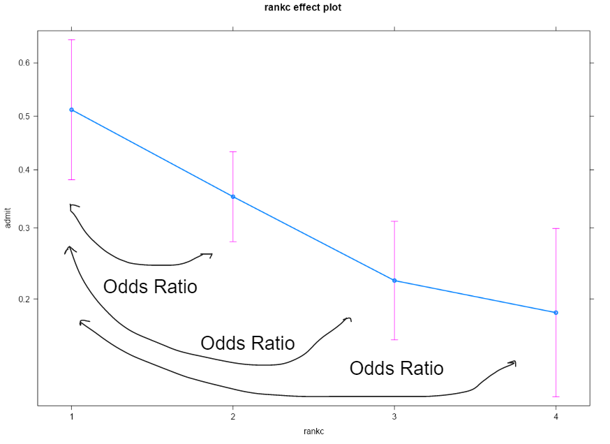

```r
plot(effects::effect("rankc", fit1))
```

However, in the presence of interactions, the odds ratio could be influenced by the `gpa` level where it is evaluated:

[figure not shown]

The model (without transformations), evaluate the effect of `rankc` when other variables are 0 and this could be meaningful or not.

Without interaction by definition the point at which I evaluate the `renkc` effect is not relevant.

[figure not shown]

# 4. Inference and model comparison for the interactions effect

Even if from the plot there is evidence for a little bit of interaction (i.e, the slopes are not the same across `rankc`) we need a statistical test. The first option is to see the Wald test of model coefficients testing if the slopes are different (e.g., `gpa:rankc2`).

To test the overall interaction we can use the `car::Anova()` function that reports main effects and interactions:

```r
car::Anova(fit1)
```

```
## Analysis of Deviance Table (Type II tests)
##
## Response: admit
##           LR Chisq Df Pr(>Chisq)
## gre         4.6290  1    0.03144 *
## gpa         5.9022  1    0.01512 *
## rankc      21.8339  3  7.063e-05 ***
## gpa:rankc   0.4125  3    0.93765
## ---
## Signif. codes:  0 '***' 0.001 '**' 0.01 '*' 0.05 '.' 0.1 ' ' 1
```

We see that as reported in the Lab 8, there are the main effects of `gre`, `gpa` and `rankc` but there is no evidence for the interaction. The `gpa:rankc` test if there is at least one slope difference that is statistically significant.

To note, the `car::Anova(fit1)` results for the interaction is just a likelihood ratio test comparing a model with the interaction vs a model without the interaction:

```r
fit_noint <- glm(admit ~ gre + gpa + rankc, family = binomial(link = "logit"), data = admission)

anova(fit_noint, fit1, test = "LRT")
```

```
## Analysis of Deviance Table
##
## Model 1: admit ~ gre + gpa + rankc
## Model 2: admit ~ gre + gpa + rankc + gpa:rankc
##   Resid. Df Resid. Dev Df Deviance Pr(>Chi)
## 1       394     458.27
## 2       391     457.86  3  0.41252   0.9376
```

In fact the `Chisq` and the `p values` are the same. The model is just testing if including the interaction reduces the residual deviance.